# Grade Difference Between Different Sections of Classes Offered in UIUC

### STAT 430: Python in Data Science Programming Final Project

**Author: Harry Jeong**

## Section 1: Dataset Description

The final dataset, df, that I have constructed for the development of the desired web app is shown below, along with the presentation of data cleaning and transformation. Explanations for each step of the manipulation is provided in comments.

```python
import pandas as pd

#import data
gpa_raw = pd.read_csv('https://raw.githubusercontent.com/wadefagen/datasets/master/gpa/uiuc-gpa-dataset.csv')

#add two new columns: quality points and class size
gpa_raw['quality points'] = gpa_raw['A+']*4 + gpa_raw['A']*4 + gpa_raw['A-']*3.67 + gpa_raw['B+']*3.33 + gpa_raw['B']*3 + gpa_raw['B-']*2.67 + gpa_raw['C+']*2.33+ gpa_raw['C']*2 + gpa_raw['C-']*1.67 + gpa_raw['D+']*1.33 + gpa_raw['D']*1 + gpa_raw['D-']*0.67
gpa_raw['class size'] = gpa_raw['A+'] + gpa_raw['A'] + gpa_raw['A-'] + gpa_raw['B+'] + gpa_raw['B'] + gpa_raw['B-'] + gpa_raw['C+'] + gpa_raw['C'] + gpa_raw['C-'] + gpa_raw['D+'] + gpa_raw['D'] + gpa_raw['D-'] + gpa_raw['F'] + gpa_raw['W']

#Use Groupby mechanics to calculate gpa by class
quality_points_sum = gpa_raw['quality points'].groupby([gpa_raw['Primary Instructor'], gpa_raw['Course Title']]).sum()
class_size_sum = gpa_raw['class size'].groupby([gpa_raw['Primary Instructor'], gpa_raw['Course Title']]).sum()
gpa_by_instructor = quality_points_sum/class_size_sum

#gbi_df presents gpa by class
gbi_df = gpa_by_instructor.reset_index()
gbi_df = gbi_df.rename(columns = {0:"GPA"})

#add number of students, Students, column to gbi_df
student_sum = class_size_sum.reset_index()
gbi_df = pd.merge(gbi_df, student_sum)
gbi_df = gbi_df.rename(columns = {"class size":"Students"})

#add frequencies of each grade to gbi_df
ap_sum = gpa_raw['A+'].groupby([gpa_raw['Primary Instructor'], gpa_raw['Course Title']]).sum().reset_index()
gbi_df = pd.merge(gbi_df, ap_sum)
a_sum = gpa_raw['A'].groupby([gpa_raw['Primary Instructor'], gpa_raw['Course Title']]).sum().reset_index()
gbi_df = pd.merge(gbi_df, a_sum)
am_sum = gpa_raw['A-'].groupby([gpa_raw['Primary Instructor'], gpa_raw['Course Title']]).sum().reset_index()
gbi_df = pd.merge(gbi_df, am_sum)
bp_sum = gpa_raw['B+'].groupby([gpa_raw['Primary Instructor'], gpa_raw['Course Title']]).sum().reset_index()
gbi_df = pd.merge(gbi_df, bp_sum)
b_sum = gpa_raw['B'].groupby([gpa_raw['Primary Instructor'], gpa_raw['Course Title']]).sum().reset_index()
gbi_df = pd.merge(gbi_df, b_sum)
bm_sum = gpa_raw['B-'].groupby([gpa_raw['Primary Instructor'], gpa_raw['Course Title']]).sum().reset_index()
gbi_df = pd.merge(gbi_df, bm_sum)
cp_sum = gpa_raw['C+'].groupby([gpa_raw['Primary Instructor'], gpa_raw['Course Title']]).sum().reset_index()
gbi_df = pd.merge(gbi_df, cp_sum)
c_sum = gpa_raw['C'].groupby([gpa_raw['Primary Instructor'], gpa_raw['Course Title']]).sum().reset_index()
gbi_df = pd.merge(gbi_df, c_sum)
cm_sum = gpa_raw['C-'].groupby([gpa_raw['Primary Instructor'], gpa_raw['Course Title']]).sum().reset_index()
gbi_df = pd.merge(gbi_df, cm_sum)
dp_sum = gpa_raw['D+'].groupby([gpa_raw['Primary Instructor'], gpa_raw['Course Title']]).sum().reset_index()
gbi_df = pd.merge(gbi_df, dp_sum)
d_sum = gpa_raw['D'].groupby([gpa_raw['Primary Instructor'], gpa_raw['Course Title']]).sum().reset_index()
gbi_df = pd.merge(gbi_df, d_sum)
dm_sum = gpa_raw['D-'].groupby([gpa_raw['Primary Instructor'], gpa_raw['Course Title']]).sum().reset_index()
gbi_df = pd.merge(gbi_df, dm_sum)
f_sum = gpa_raw['F'].groupby([gpa_raw['Primary Instructor'], gpa_raw['Course Title']]).sum().reset_index()
gbi_df = pd.merge(gbi_df, f_sum)
w_sum = gpa_raw['W'].groupby([gpa_raw['Primary Instructor'], gpa_raw['Course Title']]).sum().reset_index()
gbi_df = pd.merge(gbi_df, w_sum)

#remove unnecessary columns from gpa_raw
gpa_raw_filtered = gpa_raw.drop(['Year','Term','YearTerm','A+','A','A-','B+','B','B-','C+','C','C-','D+','D','D-','F','W','quality points','class size'],axis=1)

#merge gbi_df and gpa_raw
df = pd.merge(gbi_df, gpa_raw_filtered, how='left').drop_duplicates(subset=['Course Title', 'Primary Instructor'])
df = df.sort_values(by=['Subject','Number'])

#move columns, Subject and Number, to the front
subject_column = df['Subject']
df.drop(labels=['Subject'], axis=1, inplace = True)
df.insert(0, 'Subject', subject_column)
number_column = df['Number']
df.drop(labels=['Number'], axis=1, inplace = True)
df.insert(1, 'Number', number_column)
df = df.reset_index(drop=True)
```

```python
df
```

|  | Subject | Number | Primary Instructor | Course Title | GPA | Students | A+ | A | A- | B+ | B | B- | C+ | C | C- | D+ | D | D- | F | W |
| --- | --- | --- | --- | --- | --- | --- | --- | --- | --- | --- | --- | --- | --- | --- | --- | --- | --- | --- | --- | --- |
| 0 | AAS | 100 | Arai, Sayuri | Intro Asian American Studies | 3.643061 | 98 | 13 | 41 | 15 | 10 | 10 | 5 | 4 | 0 | 0 | 0 | 0 | 0 | 0 | 0 |
| 1 | AAS | 100 | Arnaldo, Constancio | Intro Asian American Studies | 3.579608 | 255 | 1 | 128 | 57 | 24 | 22 | 7 | 3 | 5 | 2 | 0 | 2 | 1 | 2 | 1 |
| 2 | AAS | 100 | Atienza, Paul Michael L | Intro Asian American Studies | 3.503115 | 61 | 6 | 33 | 5 | 1 | 6 | 2 | 2 | 2 | 2 | 0 | 0 | 1 | 1 | 0 |
| 3 | AAS | 100 | Boonsripaisal, Simon | Intro Asian American Studies | 3.764603 | 126 | 63 | 36 | 7 | 5 | 8 | 2 | 2 | 1 | 0 | 0 | 0 | 0 | 2 | 0 |
| 4 | AAS | 100 | Carter, Regina S | Intro Asian American Studies | 3.744894 | 47 | 11 | 25 | 6 | 2 | 0 | 0 | 0 | 0 | 0 | 2 | 0 | 1 | 0 | 0 |
| ... | ... | ... | ... | ... | ... | ... | ... | ... | ... | ... | ... | ... | ... | ... | ... | ... | ... | ... | ... | ... |
| 16189 | YDSH | 220 | Harris, Rachel S | Jewish Storytelling | 3.500985 | 132 | 23 | 21 | 49 | 14 | 13 | 6 | 2 | 0 | 0 | 0 | 0 | 0 | 3 | 1 |
| 16190 | YDSH | 220 | Murav, Harriet L | Jewish Storytelling | 3.848636 | 22 | 2 | 15 | 2 | 2 | 0 | 1 | 0 | 0 | 0 | 0 | 0 | 0 | 0 | 0 |
| 16191 | YDSH | 320 | Anderson Bliss, Jennifer | Lit Responses to the Holocaust | 3.377609 | 46 | 2 | 15 | 12 | 3 | 4 | 3 | 2 | 3 | 1 | 0 | 1 | 0 | 0 | 0 |
| 16192 | YDSH | 320 | Elliott, Jeffrey P | Lit Responses to the Holocaust | 3.924091 | 22 | 4 | 17 | 0 | 0 | 0 | 0 | 1 | 0 | 0 | 0 | 0 | 0 | 0 | 0 |
| 16193 | YDSH | 320 | Kaplan, Brett A | Lit Responses to the Holocaust | 3.288969 | 97 | 9 | 23 | 18 | 13 | 23 | 2 | 1 | 1 | 1 | 0 | 0 | 2 | 2 | 2 |

16194 rows × 20 columns

In addition to course subjects (Subject), course numbers (Number), instructors who have taught the section (Primary Instructor), and course title (Course Title), the final dataset includes a calculation of overall grades (GPA), number of students for each letter grade (A+, A, ...W), and number of students that attended each section (Students) for each of the instructor's accumulated offerings of every class presented in the raw dataset. Groupby mechanics was used to expedite the process.

Below is a list of every variable in the dataset.

- Subject
- Number
- Primary Instructor
- Course Title
- GPA
- Students
- A+
- A
- A-
- B+
- B
- B-
- C+
- C
- C-
- D+
- D
- D-
- F
- W

## Section 2: Question of Interest

The goal of my web app is plain and simple: to provide a good visualization of grade difference between different sections of a selected course.

I must admit that the provided example, Grade Disparity between sections at UIUC by Wade Fagen-Ulmschneider, has been crafted to near perfection by professor Wade and his team. However, I would like to make a bold claim that my web app can be easier on the eyes to some users. Instead of selecting only the course subject and having to drag down to whichever specific course number the user is looking for, my web app allows the user to select both course subject and number in dropdown. Once those two options are selected, the bar chart for the selected course appears subsequently in the middle of the screen. I also addded the number of students for each letter grade to the chart, where if the user hovers on the bar the data are displayed along with other information.

## Section 3: Testing of the Web App

In order to test the web app, I chose three different classes to check if the filtered dataframe from the raw dataset for each of the chosen classes matches the information provided in the web app. To be specific, I filtered the raw dataset to a specific section of a course and calculated the gpa across all offerings of the section and the sum of the number of students who have taken the section.

Below are the codes. Each set of codes is followed by the screenshot of the test case.

```python
#test1: STAT440 by David Unger
test1_df = gpa_raw.loc[(gpa_raw['Subject'] == 'STAT') & (gpa_raw['Number'] == 440) & (gpa_raw['Primary Instructor'] == 'Unger, David')]
##gpa
print(test1_df['quality points'].sum()/test1_df['class size'].sum())
##Students
print(test1_df['class size'].sum())
```

```
3.616822316555488
1649
```

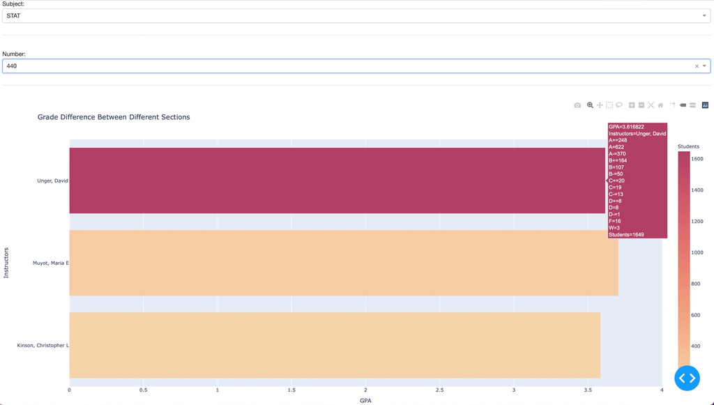

```python
#test2: ECON 426 by Rui Zhao
test2_df = gpa_raw.loc[(gpa_raw['Subject'] == 'ECON') & (gpa_raw['Number'] == 426) & (gpa_raw['Primary Instructor'] == 'Zhao, Rui')]
##gpa
print(test2_df['quality points'].sum()/test2_df['class size'].sum())
##Students
print(test2_df['class size'].sum())
```

```
3.2705405405405403
74
```

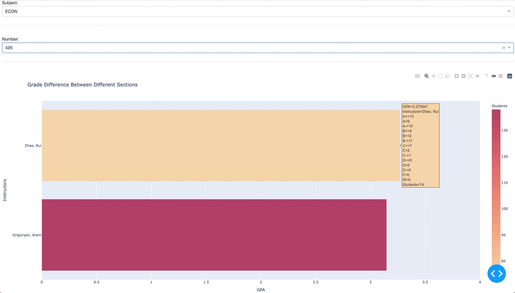

```python
#test3: CS 125 by Geoffrey W Challen
test3_df = gpa_raw.loc[(gpa_raw['Subject'] == 'CS') & (gpa_raw['Number'] == 125) & (gpa_raw['Primary Instructor'] == 'Challen, Geoffrey W')]
##gpa
print(test3_df['quality points'].sum()/test3_df['class size'].sum())
##Students
print(test3_df['class size'].sum())
```

```
3.5348156594450786
2631
```

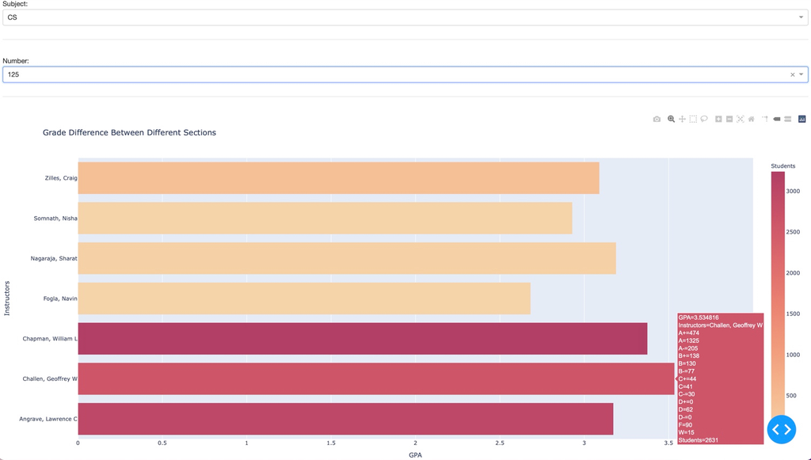

For each of the tests above, the information provided in the web app matches the data from the filtered dataframe precisely. It is clear that the app performs just as expected.

## Section 4: Conclusion & Discussion

There are improvements that can be made from my web app, though. Some useful statistics, such as median, average GPA of the course across all offered sections, percentage of students for each letter grade, etc. would make my web app more attractive. If someone is to continue working on my project, those would be the things they should tackle next.